# A Visual Story of My Spotify Listening

## Introduction

The Spotify Listening Log is a way for me to explore data on music I listened to. I created a Google Form, where every row of my data represents one piece of music I listened to and noted. Each piece of music, I noted variety of different attributes: The length of the piece of music (in seconds), the genre of the piece of music, the mood of the piece of music and on what part of the day I listened to the piece of music. The Google Form also automatically recorded a date stamp when I submitted each entry.

An important thing to note about this data is that many of my observations were collected over a short period of time, therefore, I do not intend to use this data in order to get a perfect picture of what my longterm Spotify habits are going to be. Rather, I want to use this data as a small snapshot of my music listening habits during the time I logged my entries. Thus, I want to see what patterns, if any, can be determined about genres, moods, what time of day, as well as the length of the song.

## When did I log my listening?

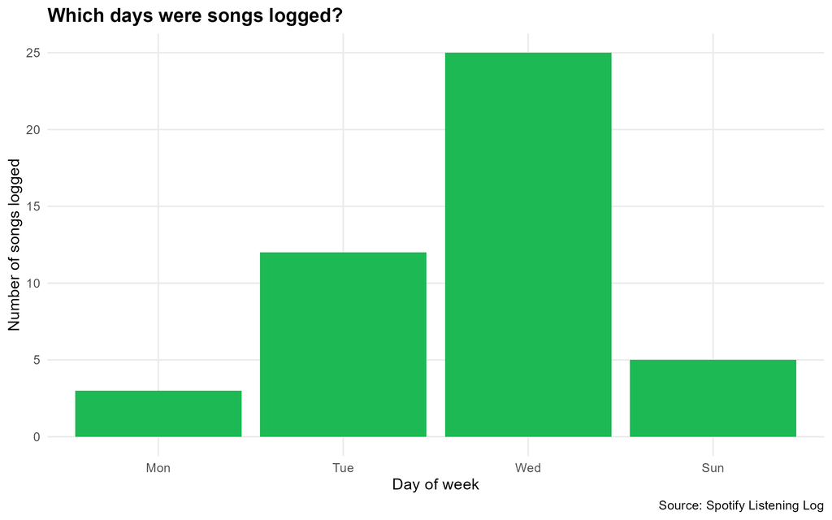

Bar chart showing how many Spotify listening observations were logged on each day of the week.

The data in the first visualization comes from the timestamp of the Google Form. I converted my observation timestamps to days of the week and plotted them so that I could see when I logged my observations. This plot represents when I recorded my observations due to the fact that I had gathered much of the data during a short time frame, therefore it cannot prove a long-term weekly listening pattern.

Though this plot cannot prove my weekly listening pattern, I included it because it also assists in explaining how I made observations. The data from the date and time fields in the Google Form provided me with a new variable, which I called day of week

## Does my song mood change across the day?

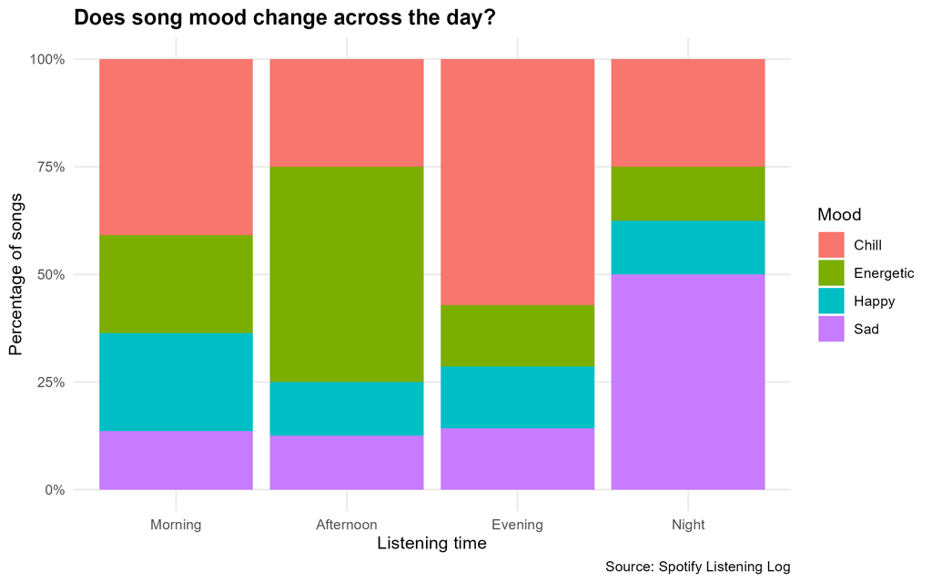

Stacked percentage bar chart showing the percentage of song moods for morning, afternoon, evening and night listening times.

This plot shows the moods of songs throughout the course of a day based on four different listening times (morning, afternoon, evening and night). A stacked percentage bar chart was chosen because it is possible for the number of songs that fall into each category to be unequal, therefore a percentage based representation will facilitate comparisons of music by mood across all times during a full day.

The plot helps to identify whether the mood of songs I was listening at different times during the day had changed. For example, if the mood was calm, energetic, happy or sad at certain times versus others.

## Which genres had longer songs?

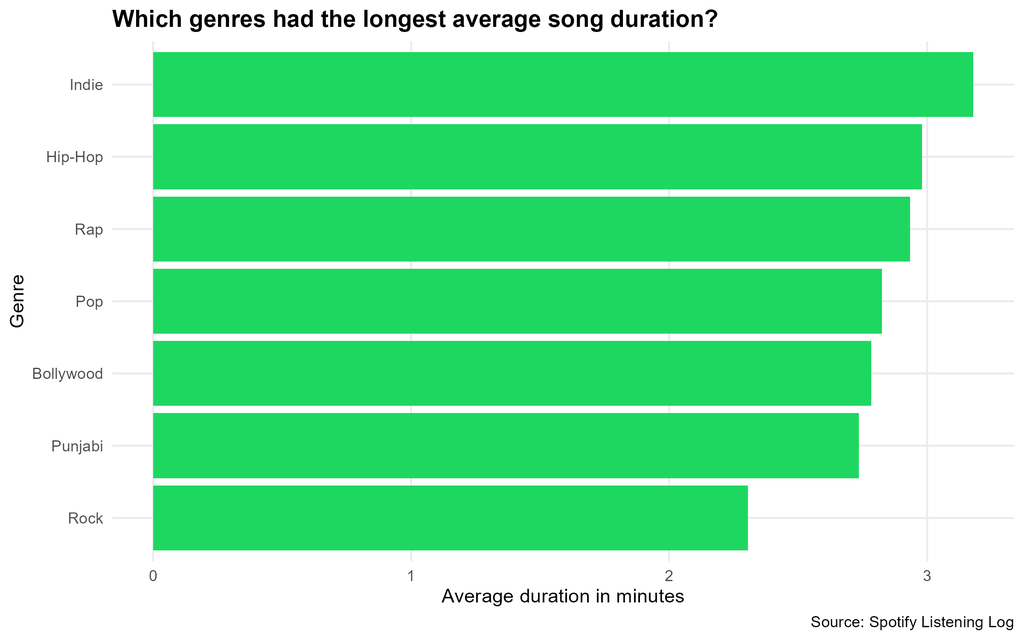

Horizontal bar chart showing the average song duration in minutes for each genre.

Each genre of music is represented on this chart with the average length of songs listed next to them in minutes, rather than seconds, making it easier to understand when looking at this chart. The songs were also placed in genres, so the average song length was calculated for each genre.

This chart is useful because it is more than just a count of songs, it also compares a number (average song length) of different genres and thus shows whether some of the genres that I have noted in my listening log, on average, had longer or shorter song lengths.

## Final thoughts

Generally speaking, this visual dataset provides an overview of my Spotify listening behaviour through a small snapshot using the viewing period of my Spotify listening activity. Because I viewed all of this data in such a short timeframe I did not feel comfortable making sweeping conclusions regarding my music preferences/how I consumed music in general; instead I preferred to focus on simple trends that could be seen within the dataset.

These three visualizations allow me to provide a cohesive storytelling experience through the combination of a plot for time of observation, a plot for comparison of musical mood by time of day, and a plot for average duration of a song, separated by genre. Thus, I have demonstrated how a limited amount of observational data can be transformed into a Visual Data Story through use of Data Modifications, Timestamps and varying Plot Types.